# COVID Infection Rates and Masking Report

2023-03-27

### 1. Summary of Findings

The data examined the relationship between masking rates and infection rates of COVID 19. The mask usage data comes from a survey conducted by the CDC in 2020 and showed, on average, 50% wore masks always with 8% of the population admitting to never wearing a mask. Vaccination rates vary across counties with the highest rate of vaccination being 95% of people reported fully vaccinated with the lowest vaccination rate being 11.3%. At the peak of the pandemic, there were 242604 cases per 100,000 people and 1480 deaths per 100,00 people.

### 2. Data and Methodology

The data measures COVID infection rates using both state and local health department reporting. The data began being compiled at the start of the pandemic, with the first case tracked on January 21, 2020. The data is organized by U.S. county. This data is combined with Centers for Disease Control data compiled via survey in 2020 regarding mask usage.

### 3. COVID Deaths and Cases to Date

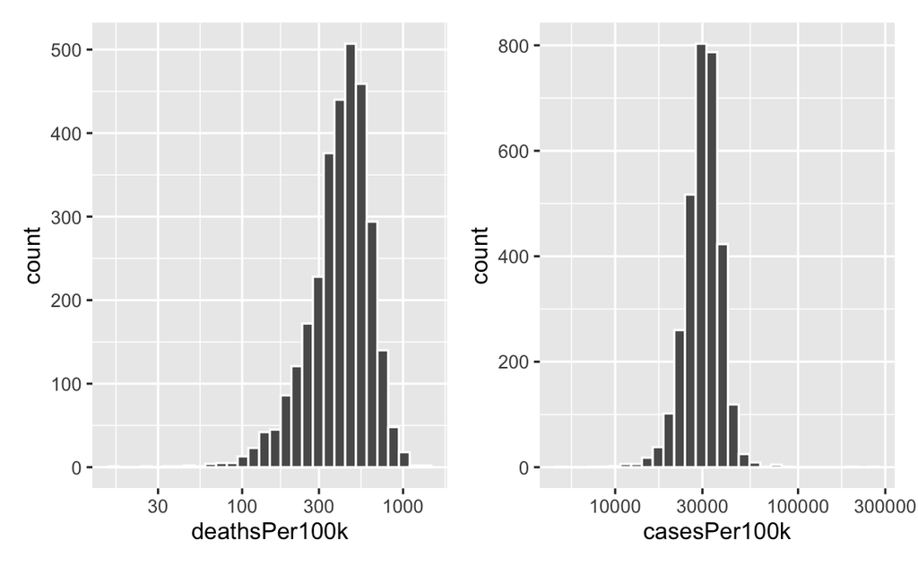

```
##    Min. 1st Qu.  Median    Mean 3rd Qu.    Max.    NA's
##     0.0   320.6   428.8   435.8   540.1  1480.5     171
```

```
##    Min. 1st Qu.  Median    Mean 3rd Qu.    Max.    NA's
##    4778   26563   30656   30950   34681  242604      93
```

Of the counties with the highest rates of deaths per 100,000 people, McMullen County and Motley County, both in Texas, represent the first and third highest death rates, respectively. It is also interesting to note, despite New York state’s early exposure to the virus, the NY county with the highest death rates ranks 1938th of 3220 counties with regard to deaths per 100000 people.

### 4. Mask Usage

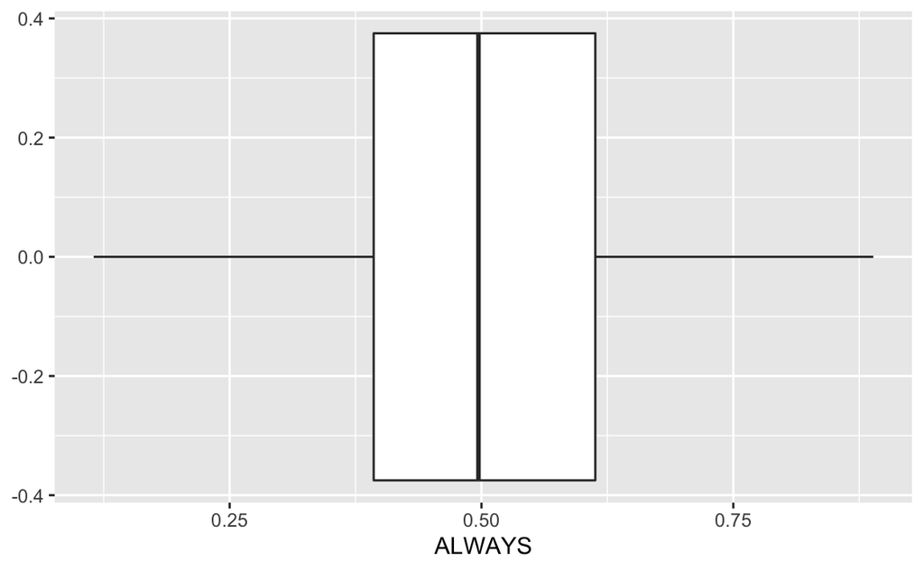

```
##    Min. 1st Qu.  Median    Mean 3rd Qu.    Max.    NA's
##  0.1150  0.3930  0.4970  0.5077  0.6130  0.8890      87
```

### 5. Vaccination Rates

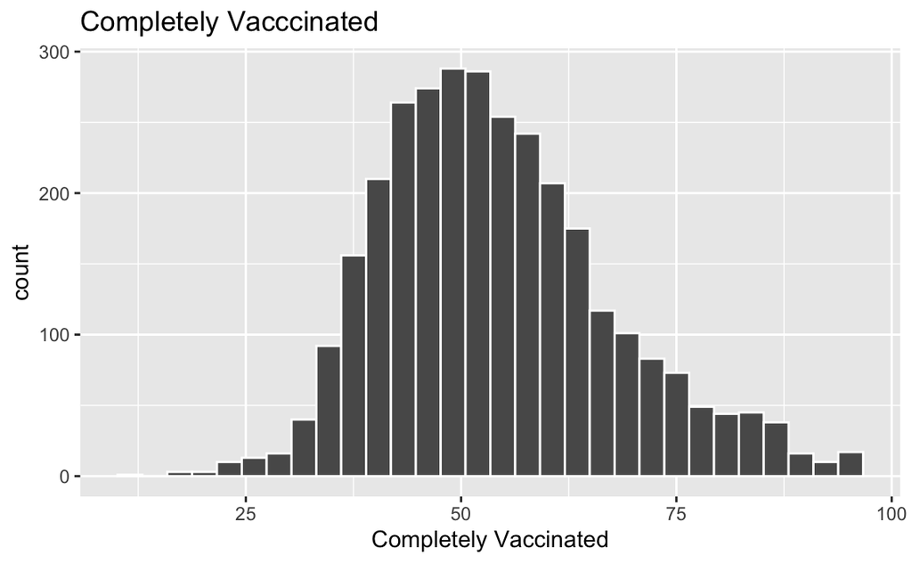

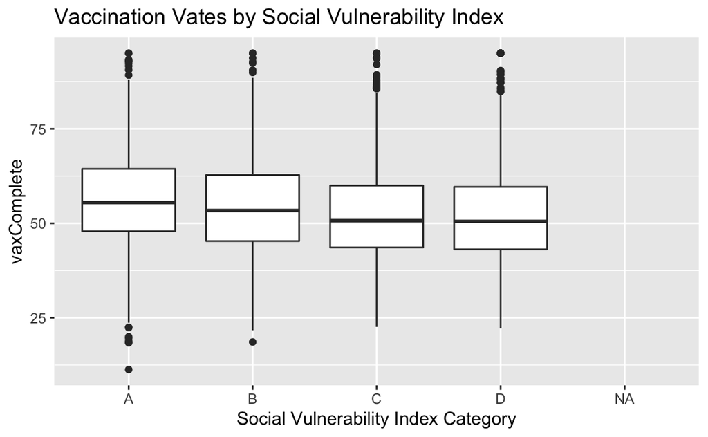

```
## # A tibble: 17 × 3
##    vaxComplete state        county
##          <dbl> <chr>        <chr>
##  1        95   Arizona      Apache
##  2        95   Arizona      Santa Cruz
##  3        95   California   Imperial
##  4        95   Colorado     San Juan
##  5        95   Georgia      Chattahoochee
##  6        95   Kansas       Geary
##  7        95   New Mexico   McKinley
##  8        11.3 North Dakota Slope
##  9        95   Puerto Rico  Culebra
## 10        95   Puerto Rico  Lares
## 11        95   Texas        Brooks
## 12        95   Texas        Irion
## 13        95   Texas        Maverick
## 14        95   Texas        Presidio
## 15        95   Texas        Starr
## 16        95   Texas        Webb
## 17        95   Wyoming      Teton
```